# Module 8 Lecture - Confidence Intervals

Introduction to Statistical Methods

Quinton Quagliano, M.S., C.S.P

Department of Educational Psychology

# 1 Overview and Introduction

Agenda

1 Overview and Introduction

2 A Single Population Mean Using the Normal Distribution

3 A Single Population Mean Using the Student t Distribution

4 A Population Proportion

5 Conclusion

## 1.1 Textbook Learning Objectives

- Calculate and interpret confidence intervals for estimating a population mean and a population proportion.
- Interpret the Student’s t probability distribution as the sample size changes.
- Discriminate between problems applying the normal and the Student’s t distributions.
- Calculate the sample size required to estimate a population mean and a population proportion given a desired confidence level and margin of error.

## 1.2 Instructor Learning Objectives

- Understand the value of calculating a confidence interval in interpreting the “accuracy” of a certain statistic
- Appreciate how the calculation and interpretation of a confidence interval builds upon our previous understanding of distributions and probability
- Value how confidence intervals demonstrate the inherently probabilistic nature of quantitative analysis in research

## 1.3 Introduction

- **Important: Professional researcher often forget just how important it is to report confidence intervals in results - but they are actually very useful in interpretation!**
- Up until now, we have primarily been working with **point estimate** of sample statistics
  - E.g., a sample statistic of a mean ($\bar{x}$) is a point estimate of the population parameter mean ($\mu$)
  - Same logic applied to standard deviation, variance, median, etc.
- Inherently, our single point estimate of a statistic is going to be insufficient for telling us much about how close it really is to the population parameter
  - Thus, we need some other part to add to the point estimate to give us more information about the population
- **Important: Remember our goal with statistics is to tell us something about the population, not just the sample!**
- This is, in essence, getting us closer to **inferential statistic**, where we can actually infer meaning from the characteristics of our sample
- The part that we need to add are called **confidence interval**
  - A confidence interval is effectively a range of values that we believe a population parameter falls in, with a certain amount of confidence
  - It is actually appropriate to refer to the confidence interval itself as a random continuous variable, as it is referring to a distribution of possible values that sample statistics can be drawn from
- **Discuss: As a review, try explaining, in your own words, what a 'random' variable is?**
- At first, we’ll talk about applications of confidence intervals to the mean, implying that we are working with continuous variables
  - We’ll touch on more categorical, discrete type stuff later

## 1.4 Nuances in the Confidence Intervals

- Commonly, we use 95 percent as the level of confidence
  - However we can use something like 99 percent for a more conservative estimate
- **Discuss: If you have taken statistics before, what other value is commonly associated with 95\%**
- Also, it is important to treat the confidence interval as another type of estimate, which we usually call a **interval estimate**
  - Just like our point estimates, there is no guarantee this in infallible
  - In fact, the confidence interval is best understood as a description of the **reliability** of sample statistics when taken from the same population, but does not mean it is certain that the population parameter falls within the range
- **Discuss: For review, describe again why we can't take sample estimates as being representative of populations? hint: use the vocabulary sample v-----**
- Depending on the field and the outlet you may see confidence intervals described as something like **margin of error**

## 1.5 Basic Calculating Confidence Intervals

- In order to calculate the confidence interval of a certain statistic, we need to know the standard error of the variable that we are interested in
  - Recall, this is the long-term standard deviation of the distribution that our statistic comes from
- However, this is most easy to know when we can assume that our variable comes from a normal distribution
  - This comes back to being able to appeal to the empirical rule that was introduced as part of understanding normal distributions
  - Remember that the empirical rule is also sometimes called the 68-95-99.7 rule
- **Discuss: Based upon the description above, try re-describing what this rule says about normal distributed variables**
- **Important: There are several slight variations on the empirical rule, but it is easiest to round things off to whole number standard deviations**
- In order to calculate the 95% confidence interval, we use the following formula:
  - $[PE - 2SE, PE + 2SE]$
  - Where $PE$: is our point estimate
  - $SE$: standard error of the statistic
  - $2SE$ is used in appeal to the empirical rule, because, theoretically, 95% of the values of the statistic fall within 2 standard deviations; we can use 1 or 3 to find the 68% or 99.7% confidence intervals, respectively
- **Important: Recall that the standard error decreases as sample size increases, which also means that a larger sample size results in a more narrow confidence interval**
- This becomes practically interpreted as 95% of the sample statistics taken from this population with the same sample size ($n$) would give us a statistic within this range 95% of the time
- For example: I have a point estimate mean statistic ($\bar{x}$) of 100, a sample size ($n$) of 40, and a population parameter standard deviation ($\sigma$) of 10
  - Review: $SE = \frac{\sigma}{\sqrt{n}}$
  - Thus: $SE = \frac{10}{\sqrt{40}} = 1.58$
  - So 95% CIs are: $[100 - 3.16, 100 + 3.16] = [96.84, 103.16]$
  - Practical interpretation: 95% of infinitely many sample statistics taken from this population will fall between 96.84 and 103.16
- **Discuss: Try following the same procedures for a point estimate mean of 50, a sample size of 12, and a population standard deviation of 20**

# 2 A Single Population Mean Using the Normal Distribution

Agenda

1 Overview and Introduction

2 A Single Population Mean Using the Normal Distribution

3 A Single Population Mean Using the Student t Distribution

4 A Population Proportion

5 Conclusion

## 2.1 Introduction

- In this section, we’ll say more to the vocabulary and specifics used in each part of the calculation process, when the population standard deviation is known
  - You may reject that we can often know the population SD, which is fair, we’ll get into that in a bit
  - For this scenario, we rely upon the central limit theorem
- We arbitrarily chose our **confidence level (CL)**, but is usually 90% or above; it is how certain we want to be that the population parameter falls within the confidence intervals
  - Based upon that CL, we can calculate the **error bound for a population mean (EBM)**, which is the amount we deviate (i.e., add or subtract) from the point estimate mean
- Another way of conceptualizing confidence level is through **alpha**
  - It is just the complement of CL: $\alpha + CL = 1$

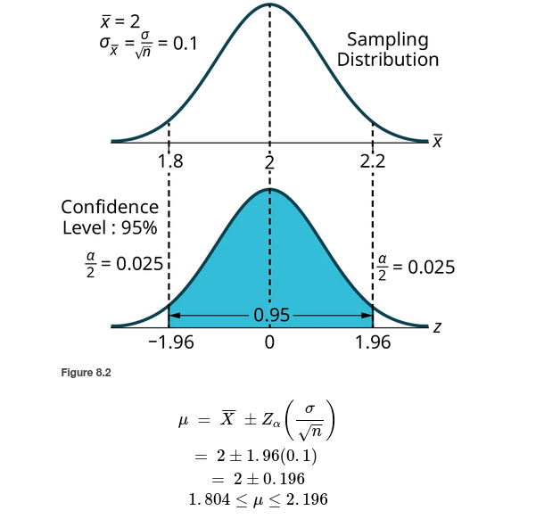

- **Important: For my folks who haven't taken stats before, alpha will show up again when we talk about p-values!**
- Consider my prior example:
  - I have a point estimate mean statistic ($\bar{x}$) of 100, a sample size ($n$) of 40, and a population parameter standard deviation ($\sigma$) of 10
    - Review: $SE = \frac{\sigma}{\sqrt{n}}$
    - Thus: $SE = \frac{10}{\sqrt{40}} = 1.58$
    - So 95% CIs are: $[100 - 3.16, 100 + 3.16] = [96.84, 103.16]$
- **Discuss: Identify what is the CL, alpha, and EBM in this worked problem**
- **Discuss: Make sure you can properly describe the different between a standard deviation of the population and the standard error of the mean**

## 2.2 Writing Z-score Notation for Confidence Intervals

- Thinking back to the image above, we split $\alpha$ between the two tails of the normal distribution
  - Thus, each tail contains $\frac{\alpha}{2}$ area, and the z-score that denotes where the CI bound is is $z_\frac{\alpha}{2}$
  - Therefore the upper 95% CI bound z is stated as $z_{\frac{0.05}{2}}$ or $x_{0.025}$
- **Discuss: Now do the same thing with a 92\% CI lower bound**

# 3 A Single Population Mean Using the Student t Distribution

Agenda

1 Overview and Introduction

2 A Single Population Mean Using the Normal Distribution

3 A Single Population Mean Using the Student t Distribution

4 A Population Proportion

5 Conclusion

## 3.1 Introduction

- As mentioned prior, we don’t often have what we can easily consider to be a reasonable population standard deviation
  - In fact, that may be one of the many things we are trying to estimate!
- **Discuss: Quickly address why you won't regularly have the population parameters and under what circumstances would you have them?**
- **William Gosset** was staff at the Guinness Brewery and, under the pen name of “Student” came up with the idea of **Student's t-distribution** to be used when the plain normal distribution didn’t work
  - Use of Student’s t-distribution is now the standard way to calculate confidence intervals for means

## 3.2 More on the t-distribution

- Theoretical steps:
  - Draw a simple random sample of size $n$
  - Population of normal distribution with parameters mean $\mu$ and standard deviation $\sigma$
  - Convert means of the distribution to t-scores with $\frac{\bar{x} - \mu}{(\frac{s}{\sqrt{n}})}$
- Results in a Student’s t-distribution with $n - 1$ **degrees of freedom (df)**
  - The individual $t$ score of a mean is understood as the distance that $\bar{x}$ is from $\mu$, like a z-score
- Degrees of freedom are a tricky concept, but come up often in most inferential statistical formulas
  - When calculating standard deviation for a sample, we calculate $n$ number of deviations and because we know that the sum of all deviations is 0 (if we don’t square them, like in the variance formula), the last deviation cannot vary.
  - Thus, all deviations ($n$) can vary until this last one, leading to $n - 1$ as the degrees of freedom in this case
- **Important: Perhaps the most defining feature of the t-distribution that separates it from the normal distribution is that it changes with the sample size**
- The notation for the t-distribution is given at $T \sim t_df$
  - Where $df = n - 1$, as previously discussed

# 4 A Population Proportion

Agenda

1 Overview and Introduction

2 A Single Population Mean Using the Normal Distribution

3 A Single Population Mean Using the Student t Distribution

4 A Population Proportion

5 Conclusion

## 4.1 Introduction

- **Important: I'm going to abridge this part a bit only because it get's a bit too 'in the weeds' for what we need to know**
- Often, we are interested not just in the confidence interval of means, but also of percentages and proportions
- First, we need to identify a situations that is more proportion-based than mean-based
  - In these scenarios, the underlying distribution is the binomial distribution
- **Discuss: For review: write the notation formula to describe a binomial distribution and describe the characteristics of that distribution**

## 4.2 Calculation of a Proportion CI

- Because of the underlying binomial, we can take a proportion as: $P' = \frac{X}{N}$
  - Where:
  - $X$ is a random variable of number of successes
  - $n$ is the number of trails/sample size
  - $P'$ is also sometimes shown as $\hat{P}$
- In the scenario that $n$ is particularly large and $p$ is not close to zero or one, we can actually treat this as normal like: $X \sim N(np, \sqrt{npq})$
- This all eventually works down to $\frac{X}{n} = P' \sim N(\frac{np}{n}, \frac{\sqrt{npq}}{n})$
  - The second part after the comma is the treated as the “standard” error for proportions
- One can calculate **error bound for a proportion (EBP)** to work towards a sort of confidence interval, but for proportions, just like we did for means

# 5 Conclusion

Agenda

1 Overview and Introduction

2 A Single Population Mean Using the Normal Distribution

3 A Single Population Mean Using the Student t Distribution

4 A Population Proportion

5 Conclusion

## 5.1 A Plea for Confidence Intervals

- I am a big advocate of the value of confidence intervals in a lot of situations - I think they appropriately capture that these statistics really are just estimates/guesses!
- In my opinion, it is pretty much always appropriate to report confidence intervals alongside the point estimates of just about anything you calculate - it increases information and transparency

## 5.2 Recap

- Confidence intervals add valuable information about the relative spread and inaccuracy of sample statistics in means and in proportions
- Confidence intervals pretty much always become more narrow with larger sample size, continuing the trends demonstrated with the central limit theorem and the law of large numbers
- We introduced the t-distribution as a valuable way to calculate confidence intervals for means, even when lacking the population standard deviation

## 5.3 Lecture Check-in

- Make sure to complete any lecture check-in tasks associated with this lecture!

[figure not shown]

Module 8 Lecture - Confidence Intervals || Introduction to Statistical Methods